# Review interpretable AI

# Loading Libraries and Packages

The first part is to load all the libraries and external functions that are required for the analysis.

```r
library(readxl)
library(RColorBrewer)
library(matrixStats)
library(partykit)
library(glmnet)
library(BOSO)


source("Code_Analysis/XAIfunctions_NV.R")

library(impute)
library(knitr)
library(reticulate)
library(readxl)
library(readr)
library(limma)
library(ggplot2)
library(ggpubr)
library(ggsci)
library(matrixStats)
library(maftools)
library(qvalue)
library(tibble)
library(Rtsne)
library(IHW)
library(matrixStats)
library(pheatmap)
library(DT)
library("dplyr")
library(tictoc)

source("./MOM/2022-05-24_MOM_source_Functions.R")
source("./MOM/predictMOM_ALL.R")
```

# Load Data

Then, we will load all the data for the analysis. Data selected was the BeatAML cohort for which we had mutational data, drug sensitivity data and gene expression data.

```r
# Load mutational data

gene_variants<-read_excel("./data/input/41586_2018_623_MOESM3_ESM.xlsx",
                          sheet="Table S7-Variants for Analysis")
clinical <- read_excel("./data/input/41586_2018_623_MOESM3_ESM.xlsx",
                       sheet = "Tabe S5-Clinical Summary")

# Load drug sensitivity data

Drug_response<-read_excel("./data/input/41586_2018_623_MOESM3_ESM.xlsx",
                          sheet="Table S10-Drug Responses")

# Load gene expression data

Expression <- read_excel("./data/input/41586_2018_623_MOESM3_ESM.xlsx",
                         sheet = "Table S8-Gene Counts RPKM")
```

# Pre-processing drug and mutational information

Now it is time to pre-process the data in order to obtain two different matrices, a matrix containing all patients and their mutations available and a second matrix containing all patients and their sensitivity to the different drugs. For doing so, we will impute the missing values in the drug matrix.

## Building the drug matrix

```r
# Build Drug Matrix

Drug<-matrix(data="NA",nrow=length(unique(Drug_response$inhibitor)),
             ncol=length(unique(Drug_response$lab_id)))

colnames(Drug)<-as.character(unique(Drug_response$lab_id))
rownames(Drug)<-unique(Drug_response$inhibitor)


for(i in as.character(unique(Drug_response$lab_id))){
  ind<-which(Drug_response$lab_id==i)
  D<-as.character(Drug_response$inhibitor[ind])
  Drug[D, i]<-Drug_response$ic50[ind]
}

#Identifying missing values

is.na(Drug) <- Drug == "NA"

#change number formatting

for(i in 2:(dim(Drug)[2]-1)){
  Drug[,i]<-as.numeric(as.character(Drug[,i]))
}
```

## Building the mutations matrix

```r
Mutations<-matrix(0, nrow=length(unique(gene_variants$labId)),
                  ncol=length(unique(gene_variants$symbol)))

rownames(Mutations)<-as.character(unique(gene_variants$labId))
colnames(Mutations)<-as.character(unique(gene_variants$symbol))


for(i in as.character(unique(gene_variants$labId))){
  jj<-unique(as.character(gene_variants$symbol[which(gene_variants$labId==i)]))
  Mutations[i, jj]<-1
}

# Add Translocations

translocations_clinical<-clinical[,c("LabId","specificDxAtAcquisition")][grep("AML with inv", clinical$specificDxAtAcquisition),]

translocations_clinical<-rbind(translocations_clinical,clinical[,c("LabId","specificDxAtAcquisition")][grep("AML with t", clinical$specificDxAtAcquisition),])

trans<-as.character(unique(translocations_clinical$specificDxAtAcquisition))
add<-matrix(0, nrow=nrow(Mutations), ncol=length(trans))
colnames(add)<-trans
rownames(add)<-rownames(Mutations)

for(j in colnames(add)){
  p<-translocations_clinical$LabId[which(translocations_clinical$specificDxAtAcquisition ==j)]
  p<-p[which(p %in% rownames(add))]
  add[p,j]<-1
}

trans<-sapply(trans, function(X){unlist(strsplit(X, split = "; "))[2]})
colnames(add)<-trans
Mutations<-cbind(Mutations,add)
```

## Unifying imputed Drug and Mutation matrices with common patients

```r
Drug_2<-as.matrix(t(Drug))
Mutations<-as.matrix(Mutations)

# impute missing values

if (sum(is.na(Drug_2))>0){
  Drug_3<-Drug_2[-which((rowSums(is.na(Drug_2))/dim(Drug_2)[2])>0.8),
                 -which((colSums(is.na(Drug_2))/dim(Drug_2)[1])>0.7)]
  Out<-impute.knn(as.matrix(Drug_3), k = 10, rowmax = 0.8,
                  colmax = 0.75, maxp = 1500, rng.seed=362436069)
  Drug_4<-Out$data[, -which(colnames(Out$data) %in% c("Elesclomol","JNJ-7706621"))]

}else{
  Drug_4<-Drug_2[, -which(colnames(Drug_2) %in% c("Elesclomol","JNJ-7706621"))]
}


# Combining Drug and mutational Data
patients<-rownames(Mutations)[which(rownames(Mutations) %in% rownames(Drug_4))]

mut<-Mutations[patients,colSums(Mutations[patients, ])>0]
mut2<-mut[, colSums(mut)>0.01*length(patients)]

sum(colSums(mut2)<1)
```

```
## [1] 0
```

```r
rm(mut)

drug<-Drug_4[patients,]
drug<-log10(drug)-1
drug <- t(t(drug) - colMeans(drug, na.rm=T))
maximum_drug_correction<-max(drug,na.rm = T)
drug<-drug-maximum_drug_correction


# Tidying up the variables

rm(list = c("Drug_2", "Drug_3", "Drug_4", "Drug_response", "Mutations", "gene_variants"))
rm(list = c("Out", "translocations_clinical", "clinical", "add", "Drug"))
```

## Pre-process gene expresison information

```r
# Keep genes with the largest variance
ngenes <- 1000
Expression <- as.data.frame(Expression)
rownames(Expression) <- Expression[,2]
Expression <- Expression[,-c(1,2)]
OldExpression <- as.matrix(Expression)
sdevs <- rowSds(OldExpression)
# sdevs <- rowMedians(OldExpression)

Keep <- which(order(sdevs, decreasing = T) <= ngenes)
Expression <- Expression[Keep,]

commonPatients <- intersect(rownames(drug), colnames(Expression))
```

## Create variables for model training

```r
C <- drug - min(drug)
X <- mut2

Y <- exp(-.5*C) # Convert weights into pseudoprobabilities for Multinomial
Y <- Y /rowSums(Y) # Probabilities sum up one
```

# Comparison of methods with Cross-Validation

We performed a 5-fold cross-validation using the BeatAML dataset. We trained all models with genetic variants data from 319 patients, dividing the cohort between the training samples 4-folds and testing samples the selected 1-fold. Each of the folds were tested, and the predicted IC50* for the 5-fold testing was compared for all the methods and compared against the Oracle -the drug with the optimum IC50*-.

We calculated the Oracle as the minimum IC50* value for each patient.

Results from MOM and KRL were directly loaded into the workspace due to the computing limitations in R.

```r
set.seed(2022)
Folds <- 5
Groups <- sample(1:Folds, nrow(C), replace = T)
TratamientoMnLassoMut <- TratamientoLassoMut <- TratamientoTreeMut <- TratamientoTreeMut1 <- rep(NA, length(Groups))

for (group in 1:Folds) {
  cat("Fold: ", group, "\n")
  Dejar <- Groups != group
  Quitar <- !Dejar

  # TreesMut
  cat("TreesMut\n")
  treeMut <- trainTreeMut(X[Dejar,], C[Dejar,], minbucket = 10)
  TratamientoTreeMut[Quitar] <- predictTreeMut(treeMut,C[Quitar,], X[Quitar,])

  # TreesMut sqrt
  cat("TreesMut sqrt\n")
  treeMut1 <- trainTreeMut(X[Dejar,], (C[Dejar,])^.5, minbucket = 10)
  TratamientoTreeMut1[Quitar] <- predictTreeMut(treeMut1,C[Quitar,], X[Quitar,])

  # Using MnLasso
  cat("Multinomial Lasso Mut\n")
  MnLassoMut <- trainMnLasso(X[Dejar,], Y[Dejar,])
  TratamientoMnLassoMut[Quitar] <- predictMnLasso(MnLassoMut,X[Quitar,])

  # Using Lasso
  cat("Lasso Mut\n")
  LassoMut <- trainLasso(X[Dejar,], C[Dejar,])
  TratamientoLassoMut[Quitar] <- predictLasso(LassoMut,X[Quitar,])

}
```

```
## Fold:  1
## TreesMut
## TreesMut sqrt
## Multinomial Lasso Mut
## Lasso Mut
## Fold:  2
## TreesMut
## TreesMut sqrt
## Multinomial Lasso Mut
## Lasso Mut
## Fold:  3
## TreesMut
## TreesMut sqrt
## Multinomial Lasso Mut
## Lasso Mut
## Fold:  4
## TreesMut
## TreesMut sqrt
## Multinomial Lasso Mut
## Lasso Mut
## Fold:  5
## TreesMut
## TreesMut sqrt
## Multinomial Lasso Mut
## Lasso Mut
```

```r
# Use same groups as previously
TratamientoBOSOMut <- rep(NA, length(Groups))

for (group in 1:Folds) {
  cat("Fold: ", group, "\n")
  Dejar <- Groups != group
  Quitar <- !Dejar
  BOSOMut <- trainBOSO(X[Dejar,], C[Dejar,],maxVarsBlock = 10, standardize=F, IC = "eBIC")
  TratamientoBOSOMut[Quitar] <- predictBOSO(BOSOMut, X[Quitar,])
}
```

```
## Fold:  1
## 17-AAG (Tanespimycin)
## Iteration 1   number of variables: 69     block size: 10
## Final problem:    number of variables: 4
## Elapsed time: 2.365325 secs
## A-674563
## Iteration 1   number of variables: 69     block size: 10
## Final problem:    number of variables: 6
## Elapsed time: 5.658415 secs
## ABT-737
## Iteration 1   number of variables: 69     block size: 10
## Final problem:    number of variables: 1
## Elapsed time: 6.781111 secs
## AT7519
## Iteration 1   number of variables: 69     block size: 10
## Final problem:    number of variables: 2
## Elapsed time: 8.176143 secs
## AZD1480
## Iteration 1   number of variables: 69     block size: 10
## Final problem:    number of variables: 3
## Elapsed time: 10.05812 secs
## Afatinib (BIBW-2992)
## Iteration 1   number of variables: 69     block size: 10
## Final problem:    number of variables: 1
## Elapsed time: 11.15826 secs
## Alisertib (MLN8237)
## Iteration 1   number of variables: 69     block size: 10
## Final problem:    number of variables: 2
## Elapsed time: 12.49009 secs
## Axitinib (AG-013736)
## Iteration 1   number of variables: 69     block size: 10
## Final problem:    number of variables: 4
## Elapsed time: 14.58146 secs
## BEZ235
## Iteration 1   number of variables: 69     block size: 10
## Elapsed time: 15.30157 secs
## BMS-345541
## Iteration 1   number of variables: 69     block size: 10
## Final problem:    number of variables: 2
## Elapsed time: 16.54217 secs
```

[output cut: 2138 more lines]

```
## Iteration 1   number of variables: 69     block size: 10
## Final problem:    number of variables: 1
## Elapsed time: 3.900368 mins
## Volasertib (BI-6727)
## Iteration 1   number of variables: 69     block size: 10
## Final problem:    number of variables: 2
## Elapsed time: 3.922391 mins
## XAV-939
## Iteration 1   number of variables: 69     block size: 10
## Final problem:    number of variables: 1
## Elapsed time: 3.942535 mins
## YM-155
## Iteration 1   number of variables: 69     block size: 10
## Final problem:    number of variables: 3
## Elapsed time: 3.969487 mins
```

```r
load("./data/output/mom_COMPARISON.RData")

# KRL
KRL_results_cv <- read_csv("data/output/KRL_results_5cv_samples_prediction.csv")
KRL_all<-read_csv("data/output/KRL_results_all_samples_prediction.csv")
KRL_results_cv<-KRL_results_cv[which(KRL_results_cv$Patients %in% rownames(mut2)),]
KRL_all<-KRL_all[which(KRL_all$Patients %in% rownames(mut2)),]

KRL_results_cv<-KRL_results_cv[which(KRL_results_cv$DrugName %in% colnames(drug)),]
KRL_all<-KRL_all[which(KRL_all$DrugName %in% colnames(drug)),]


KRL_all$`Best Drug`<-KRL_all$`Best Drug`+1
KRL_results_cv$Drug<-KRL_results_cv$Drug+1


KRL_all$IC50<-C[cbind(KRL_all$Patients, KRL_all$DrugName)]
KRL_results_cv$IC50<-C[cbind(KRL_results_cv$Patients, KRL_results_cv$DrugName)]


TratamientoOracle <- apply(C, 1, which.min)
```

## Plotting BeatAML Cross-validation Results and comparing means difference

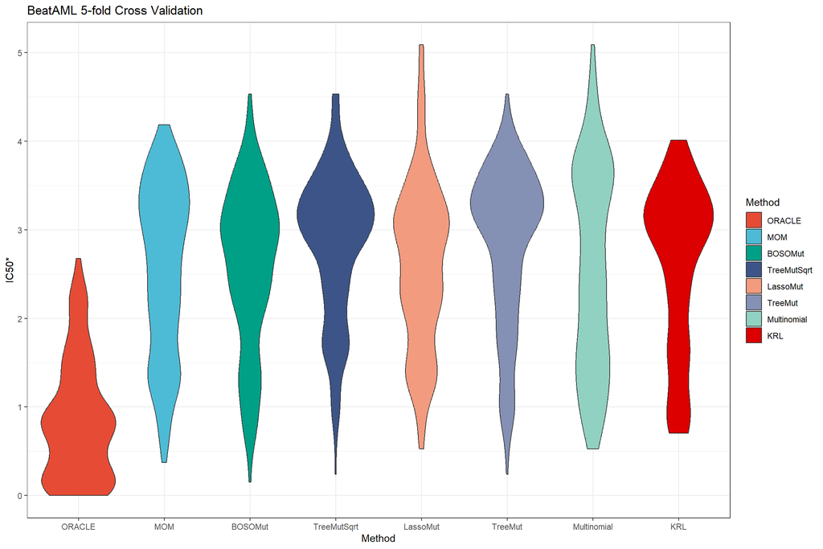

```r
Tratamiento_plot<-data.frame(Method="ORACLE", IC50=C[cbind(1:nrow(C),TratamientoOracle)])
Tratamiento_plot<-rbind(Tratamiento_plot,data.frame(Method="TreeMut", IC50=C[cbind(1:nrow(C), TratamientoTreeMut)]))
Tratamiento_plot<-rbind(Tratamiento_plot,data.frame(Method="TreeMutSqrt", IC50=C[cbind(1:nrow(C), TratamientoTreeMut1)]))
Tratamiento_plot<-rbind(Tratamiento_plot,data.frame(Method="Multinomial", IC50=C[cbind(1:nrow(C), TratamientoMnLassoMut)]))
Tratamiento_plot<-rbind(Tratamiento_plot,data.frame(Method="LassoMut", IC50=C[cbind(1:nrow(C), TratamientoLassoMut)]))
Tratamiento_plot<-rbind(Tratamiento_plot,data.frame(Method="BOSOMut", IC50=C[cbind(1:nrow(C), TratamientoBOSOMut)]))
Tratamiento_plot<-rbind(Tratamiento_plot,data.frame(Method="MOM", IC50=MOM$IC50))
Tratamiento_plot<-rbind(Tratamiento_plot,data.frame(Method="KRL", IC50=KRL_results_cv$IC50))


Tratamiento_plot$Method<-factor(Tratamiento_plot$Method, levels=c("ORACLE", "MOM", "BOSOMut", "TreeMutSqrt", "LassoMut", "TreeMut", "Multinomial","KRL"))

ggplot(Tratamiento_plot, aes(x=Method, y=IC50, fill=Method))+geom_violin()+
  theme_bw()+scale_fill_npg()+ylab("IC50*")+ggtitle("BeatAML 5-fold Cross Validation")
```

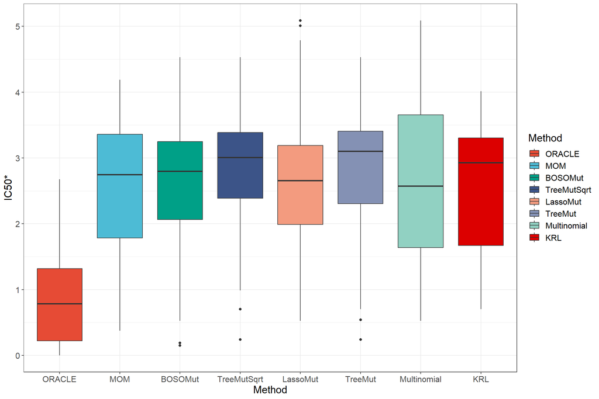

```r
ggplot(Tratamiento_plot, aes(x=Method, y=IC50, fill=Method))+geom_boxplot()+
  theme_bw()+scale_fill_npg()+ylab("IC50*")+theme(text = element_text(size = 15))
```

```r
wilcox.test(Tratamiento_plot$IC50[Tratamiento_plot$Method=="ORACLE"],
            Tratamiento_plot$IC50[Tratamiento_plot$Method=="MOM"], alternative="less")
```

```
##
##  Wilcoxon rank sum test with continuity correction
##
## data:  Tratamiento_plot$IC50[Tratamiento_plot$Method == "ORACLE"] and Tratamiento_plot$IC50[Tratamiento_plot$Method == "MOM"]
## W = 8757.5, p-value < 2.2e-16
## alternative hypothesis: true location shift is less than 0
```

```r
wilcox.test(Tratamiento_plot$IC50[Tratamiento_plot$Method=="ORACLE"],
            Tratamiento_plot$IC50[Tratamiento_plot$Method=="BOSOMut"], alternative="less")
```

```
##
##  Wilcoxon rank sum test with continuity correction
##
## data:  Tratamiento_plot$IC50[Tratamiento_plot$Method == "ORACLE"] and Tratamiento_plot$IC50[Tratamiento_plot$Method == "BOSOMut"]
## W = 7628, p-value < 2.2e-16
## alternative hypothesis: true location shift is less than 0
```

```r
wilcox.test(Tratamiento_plot$IC50[Tratamiento_plot$Method=="ORACLE"],
            Tratamiento_plot$IC50[Tratamiento_plot$Method=="TreeMutSqrt"], alternative="less")
```

```
##
##  Wilcoxon rank sum test with continuity correction
##
## data:  Tratamiento_plot$IC50[Tratamiento_plot$Method == "ORACLE"] and Tratamiento_plot$IC50[Tratamiento_plot$Method == "TreeMutSqrt"]
## W = 4058, p-value < 2.2e-16
## alternative hypothesis: true location shift is less than 0
```

```r
wilcox.test(Tratamiento_plot$IC50[Tratamiento_plot$Method=="ORACLE"],
            Tratamiento_plot$IC50[Tratamiento_plot$Method=="LassoMut"], alternative="less")
```

```
##
##  Wilcoxon rank sum test with continuity correction
##
## data:  Tratamiento_plot$IC50[Tratamiento_plot$Method == "ORACLE"] and Tratamiento_plot$IC50[Tratamiento_plot$Method == "LassoMut"]
## W = 6995, p-value < 2.2e-16
## alternative hypothesis: true location shift is less than 0
```

```r
wilcox.test(Tratamiento_plot$IC50[Tratamiento_plot$Method=="ORACLE"],
            Tratamiento_plot$IC50[Tratamiento_plot$Method=="TreeMut"], alternative="less")
```

```
##
##  Wilcoxon rank sum test with continuity correction
##
## data:  Tratamiento_plot$IC50[Tratamiento_plot$Method == "ORACLE"] and Tratamiento_plot$IC50[Tratamiento_plot$Method == "TreeMut"]
## W = 5379.5, p-value < 2.2e-16
## alternative hypothesis: true location shift is less than 0
```

```r
wilcox.test(Tratamiento_plot$IC50[Tratamiento_plot$Method=="ORACLE"],
            Tratamiento_plot$IC50[Tratamiento_plot$Method=="Multinomial"], alternative="less")
```

```
##
##  Wilcoxon rank sum test with continuity correction
##
## data:  Tratamiento_plot$IC50[Tratamiento_plot$Method == "ORACLE"] and Tratamiento_plot$IC50[Tratamiento_plot$Method == "Multinomial"]
## W = 10271, p-value < 2.2e-16
## alternative hypothesis: true location shift is less than 0
```

```r
wilcox.test(Tratamiento_plot$IC50[Tratamiento_plot$Method=="ORACLE"],
            Tratamiento_plot$IC50[Tratamiento_plot$Method=="KRL"], alternative="less")
```

```
##
##  Wilcoxon rank sum test with continuity correction
##
## data:  Tratamiento_plot$IC50[Tratamiento_plot$Method == "ORACLE"] and Tratamiento_plot$IC50[Tratamiento_plot$Method == "KRL"]
## W = 8190, p-value < 2.2e-16
## alternative hypothesis: true location shift is less than 0
```

# Independent Cohort Validation

One of the main challenges of Machine Learning, including Precision Medicine, is generalization, i.e. the ability to adapt to new, previously unseen data. All the methods were tested on the GDSC AML dataset to check their generalization ability. The models were trained using the BeatAML dataset and were used to predict the optimal drug for AML cell lines from GDSC using its mutation files. Each of the cell lines was recommended a drug, we compared the all-samples IC50 for all the models and against the Oracle (the drug with the minimum IC50 for each cell line).

## Training models in complete BeatAML data and timing

We trained the models in BeatAML cohort and measured the training time for each model except KRL and MOM, that were meassured independently. Technical implementation refers to the computational burden and software that the method requires.Despite it could be considered less important, some of the algorithms require hours of computing time for the BeatAML of the subset of AML samples in GDSC -that be considered to be small/medium size.

```r
# Train with all the data

# TreesMut
cat("TreesMut\n")
```

```
## TreesMut
```

```r
tic()
treeMut_All <- trainTreeMut(X, C, minbucket = 10)
TratamientoTreeMut_ALL <- predictTreeMut(treeMut_All,C, X)
toc()
```

```
## 0.03 sec elapsed
```

```r
# TreesMut sqrt
cat("TreesMut sqrt\n")
```

```
## TreesMut sqrt
```

```r
tic()
treeMut1_All <- trainTreeMut(X, (C)^.5, minbucket = 10)
TratamientoTreeMut1_All <- predictTreeMut(treeMut1_All,C, X)
toc()
```

```
## 0.03 sec elapsed
```

```r
# Using MnLasso
cat("Multinomial Lasso Mut\n")
```

```
## Multinomial Lasso Mut
```

```r
tic()
MnLassoMut_All <- trainMnLasso(X, Y)
TratamientoMnLassoMut_All <- predictMnLasso(MnLassoMut_All,X)
toc()
```

```
## 14.03 sec elapsed
```

```r
# Using Lasso
cat("Lasso Mut\n")
```

```
## Lasso Mut
```

```r
tic()
LassoMut_All <- trainLasso(X, C)
TratamientoLassoMut_All <- predictLasso(LassoMut_All,X)
toc()
```

```
## 13.77 sec elapsed
```

```r
# Use same groups as previously
TratamientoBOSOMut_All <- rep(NA, length(Groups))
tic()
BOSOMut_All <- trainBOSO(X, C,maxVarsBlock = 10, standardize=F, IC = "eBIC")
```

```
## 17-AAG (Tanespimycin)
## Iteration 1   number of variables: 69     block size: 10
## Final problem:    number of variables: 3
## Elapsed time: 1.946765 secs
## A-674563
## Iteration 1   number of variables: 69     block size: 10
## Final problem:    number of variables: 5
## Elapsed time: 4.370383 secs
## ABT-737
## Iteration 1   number of variables: 69     block size: 10
## Final problem:    number of variables: 3
## Elapsed time: 6.342369 secs
## AT7519
## Iteration 1   number of variables: 69     block size: 10
## Final problem:    number of variables: 1
## Elapsed time: 7.481878 secs
## AZD1480
## Iteration 1   number of variables: 69     block size: 10
## Final problem:    number of variables: 3
## Elapsed time: 9.310016 secs
## Afatinib (BIBW-2992)
## Iteration 1   number of variables: 69     block size: 10
## Final problem:    number of variables: 3
## Elapsed time: 10.94647 secs
## Alisertib (MLN8237)
## Iteration 1   number of variables: 69     block size: 10
## Final problem:    number of variables: 5
## Elapsed time: 13.21833 secs
## Axitinib (AG-013736)
## Iteration 1   number of variables: 69     block size: 10
## Final problem:    number of variables: 5
## Elapsed time: 15.76148 secs
## BEZ235
## Iteration 1   number of variables: 69     block size: 10
## Final problem:    number of variables: 3
## Elapsed time: 17.54717 secs
## BMS-345541
## Iteration 1   number of variables: 69     block size: 10
## Final problem:    number of variables: 2
## Elapsed time: 19.10841 secs
```

[output cut: 381 more lines]

```
## Elapsed time: 3.797134 mins
## Vismodegib (GDC-0449)
## Iteration 1   number of variables: 69     block size: 10
## Elapsed time: 3.812402 mins
## Volasertib (BI-6727)
## Iteration 1   number of variables: 69     block size: 10
## Final problem:    number of variables: 2
## Elapsed time: 3.835449 mins
## XAV-939
## Iteration 1   number of variables: 69     block size: 10
## Elapsed time: 3.851703 mins
## YM-155
## Iteration 1   number of variables: 69     block size: 10
## Final problem:    number of variables: 3
## Elapsed time: 3.883902 mins
```

```r
TratamientoBOSOMut_All <- predictBOSO(BOSOMut_All, X)
toc()
```

```
## 233.06 sec elapsed
```

## Validation in GDSC

The models were trained using the BeatAML dataset and were used to predict the optimal drug for AML cell lines from GDSC using its mutation files. Each of the cell lines was recommended a drug, we compared the all-samples IC50 for all the models and against the Oracle (the drug with the minimum IC50 for each cell line). The function `predictMOM_ALL`. Applies the decision tree generated by MOM in AML.

### Load GDSC and CCLE data

```r
GDSC1_ESS<-read.csv("./data/input/LAML_IC_Wed Nov 24 10_31_42 2021.csv")
GDSC1_MUT<-read.csv("./data/input/LAML_Genetic_feature_variant_Wed Nov 24 GDSC1.csv")



load("./data/input/DEMETER2/Processed/new_CCLE_DEMETER2_20Q3_SYNLETHDB_data_v1.Rdata")
CCLE_mutation_data <- demeter2_mut

CCLE_mutation_data[c("MV411_HAEMATOPOIETIC_AND_LYMPHOID_TISSUE","NOMO1_HAEMATOPOIETIC_AND_LYMPHOID_TISSUE","OCIAML2_HAEMATOPOIETIC_AND_LYMPHOID_TISSUE"),"TP53"]   <- 1
CCLE_mutation_data["HL60_HAEMATOPOIETIC_AND_LYMPHOID_TISSUE","KDM6A"]  <- 1
CCLE_mutation_data[c("MOLM13_HAEMATOPOIETIC_AND_LYMPHOID_TISSUE","MV411_HAEMATOPOIETIC_AND_LYMPHOID_TISSUE"),"FLT3"]   <- 1
CCLE_mutation_data["NOMO1_HAEMATOPOIETIC_AND_LYMPHOID_TISSUE","KRAS"]   <- 1

rm(demeter2_mut, demeter2_scores, demeter2_fus)
```

### Biomarker Pre-processing

We build the mutations matrix and complete that information with CCLE mutational data.

```r
# Biomarker pre-processing and adding CCLE information

aux_gdsc<-data.frame(cell_line_name="ME-1",
                     cosmic_sample_id="1330942",
                     gdsc_desc1="blood",
                     gdsc_desc2="acute_myeloid_leukaemia",
                     tcga_desc="LAML",
                     genetic_feature="CBFB-MYH11_mut",
                     is_mutated="1",
                     recurrent_gain_loss=NA,
                     genes_in_segment=NA)

BMVal<-rbind(GDSC1_MUT,aux_gdsc)

BMVal$cell_line_name<-sapply(BMVal$cell_line_name, FUN=function(X){return(paste(unlist(strsplit(X, split="-")), collapse=""))})

BMVal$cell_line_name<-paste0(BMVal$cell_line_name, "_HAEMATOPOIETIC_AND_LYMPHOID_TISSUE")


BM_matrix<-matrix(0,
                  nrow=length(unique(BMVal$cell_line_name)),
                  ncol=ncol(mut2))

colnames(BM_matrix)<-colnames(mut2)
rownames(BM_matrix)<-as.character(unique(BMVal$cell_line_name))

for(k in 1:nrow(BM_matrix)){
  c<-rownames(BM_matrix)[k]
  for(m in 1:ncol(BM_matrix)){
    bm_ccle<-colnames(BM_matrix)[m]
    bm<-paste0(bm_ccle, "_mut")
    aux<-BMVal$is_mutated[which(BMVal$cell_line_name==c & BMVal$genetic_feature==bm)]

    if((bm_ccle %in% colnames(CCLE_mutation_data))&& (c %in% rownames(CCLE_mutation_data))){
      aux_ccle<-CCLE_mutation_data[c, bm_ccle]
    }else{
      aux_ccle<-NULL
    }
    if(length(aux_ccle)<1 && length(aux)<1){next}
    if(max(aux,aux_ccle)==1){
      BM_matrix[k,m]<-as.numeric(max(aux,aux_ccle))
    }
    aux<-NULL
    aux_ccle<-NULL
  }
}


BM_matrix<-BM_matrix[,match( colnames(BM_matrix),colnames(mut2))]
# colnames(BM_matrix)<-sapply(colnames(BM_matrix), FUN=function(X){return(unlist(strsplit(X, split="_"))[1])})

Mutations_AML_GDSC<-BM_matrix
```

### Drug information pre-processing

```r
GDSC1_ESS$Cell.line.name<-sapply(GDSC1_ESS$Cell.line.name, FUN=function(X){return(paste(unlist(strsplit(X, split="-")), collapse=""))})

GDSC1_ESS$Cell.line.name<-paste0(GDSC1_ESS$Cell.line.name, "_HAEMATOPOIETIC_AND_LYMPHOID_TISSUE")



Ess_matrix<-matrix(50000,
                   nrow=length(unique(GDSC1_ESS$Cell.line.name)),
                   ncol=length(unique(GDSC1_ESS$Drug.name)))


colnames(Ess_matrix)<-as.character(unique(GDSC1_ESS$Drug.name))
rownames(Ess_matrix)<-as.character(unique(GDSC1_ESS$Cell.line.name))

for(k in 1:nrow(Ess_matrix)){
  c<-rownames(Ess_matrix)[k]
  for(m in 1:ncol(Ess_matrix)){
    d<-colnames(Ess_matrix)[m]
    aux<-GDSC1_ESS$IC50[which(GDSC1_ESS$Cell.line.name==c & GDSC1_ESS$Drug.name==d)]
    aux<-mean(as.numeric(aux))
    if(length(aux)<1){next}
    Ess_matrix[k,m]<-aux
    aux<-NULL
  }
}

Ess_matrix[Ess_matrix=="NaN"]<-NA
# Impute Missing Data for Validation

Ess_matrix<-Ess_matrix[-which((rowSums(is.na(Ess_matrix))/dim(Ess_matrix)[2])>0.8),
                       -which((colSums2(is.na(Ess_matrix))/dim(Ess_matrix)[1])>0.70)]


Out_gdsc<-impute.knn(as.matrix(Ess_matrix), k = 10, rowmax = 0.75,
                     colmax = 0.8, maxp = 1500, rng.seed=362436069)

colnames(Out_gdsc$data)[which(colnames(Out_gdsc$data)=="Venotoclax")]<-"Venetoclax"

GDSC_AML<-Out_gdsc$data
GDSC_AML<-t(t(GDSC_AML)-colMeans(GDSC_AML))

drugsGDSC<-sapply(colnames(C), FUN=function(X){return(unlist(strsplit(X, split=" "))[1])})

GDSC_AML<-GDSC_AML[,na.omit(match(drugsGDSC, colnames(GDSC_AML)))]

colnamesGDSC<-colnames(C)[match(colnames(GDSC_AML),drugsGDSC)]


colnames(GDSC_AML)<-colnamesGDSC


GDSC_AML<-GDSC_AML[which(rownames(GDSC_AML) %in% rownames(Mutations_AML_GDSC)),]
GDSC_AML<-GDSC_AML[match(rownames(Mutations_AML_GDSC), rownames(GDSC_AML)),]


identical(rownames(GDSC_AML), rownames(Mutations_AML_GDSC))
```

```
## [1] TRUE
```

### Make Predictions with the models

We useed the models trained in BeatAML to predict over GDSC.

```r
identical(colnames(Mutations_AML_GDSC), colnames(mut2)) #TRUE
```

```
## [1] TRUE
```

```r
Guideline_TreeMutSqrt<-predictTreeMut(treeMut1_All,C, Mutations_AML_GDSC)
Guideline_TreeMutSqrt<-colnames(C)[Guideline_TreeMutSqrt]


Guideline_BOSO<-predictBOSO(BOSOMut_All,Mutations_AML_GDSC)
Guideline_BOSO<-colnames(C)[Guideline_BOSO]

Guideline_TreeMut<-predictTreeMut(treeMut_All,C, Mutations_AML_GDSC)
Guideline_TreeMut<-colnames(C)[Guideline_TreeMut]

Guideline_Multinomial<-predictMnLasso(MnLassoMut_All, Mutations_AML_GDSC)
Guideline_Multinomial<-colnames(C)[Guideline_Multinomial]

Guideline_Lasso<-predictLasso(LassoMut_All, Mutations_AML_GDSC)
Guideline_Lasso<-colnames(C)[Guideline_Lasso]

Guideline_MOM<-predictMOM_ALL(Mutations_AML_GDSC)
```

```
##
##
##  Assuming Optimal BeatAML Classification
##
```

```r
Guideline_MOM<-colnames(C)[Guideline_MOM$Treatment]

Guideline_KRL<-read_csv("data/output/KRL_GDSC_pred.csv")
Guideline_KRL$DrugName[which(!(Guideline_KRL$DrugName %in% colnames(C)))]<-NA
Guideline_KRL<-Guideline_KRL$DrugName
```

### Obtain Prediction $IC_{50}$ values

We will now obtain the GDSC $IC_{50}$ values corresponding to the predicted treatments

```r
# Validate the Guidelines..................................................

identical(rownames(GDSC_AML), rownames(Mutations_AML_GDSC)) # TRUE
```

```
## [1] TRUE
```

```r
GDSC_IC50<-data.frame(CL=rownames(Mutations_AML_GDSC),
                      TreeMut=NA,
                      TreeMutSqrt=NA,
                      MnLasso=NA,
                      BOSO=NA,
                      Lasso=NA,
                      MOM=NA,
                      KRL=NA,
                      ORACLE=NA)

for(i in 1:nrow(GDSC_IC50)){
  CL<-GDSC_IC50$CL[i]

  # TreeMut
  dtreeMut<-Guideline_TreeMut[i]
  if(dtreeMut %in% colnames(GDSC_AML)){
    GDSC_IC50$TreeMut[i]<-GDSC_AML[CL,dtreeMut]
  }


  # TreeMutSqrt
  dtreeMutSQrt<-Guideline_TreeMutSqrt[i]
  GDSC_IC50$TreeMutSqrt[i]<-GDSC_AML[CL,dtreeMutSQrt]

  # Multinomial
  dMultinomial<-Guideline_Multinomial[i]
  if(dMultinomial %in% colnames(GDSC_AML)){
    GDSC_IC50$MnLasso[i]<-GDSC_AML[CL,dMultinomial]
  }



  # BOSO
  dBOSO<-Guideline_BOSO[i]
  if(dBOSO %in% colnames(GDSC_AML)){
    GDSC_IC50$BOSO[i]<-GDSC_AML[CL,dBOSO]
  }



  # Lasso
  dLasso<-Guideline_Lasso[i]
  if(dLasso %in% colnames(GDSC_AML)){
    GDSC_IC50$Lasso[i]<-GDSC_AML[CL,dLasso]
  }

  #MOM
  dMOM<-Guideline_MOM[i]
  GDSC_IC50$MOM[i]<-GDSC_AML[CL,dMOM]

  #KRL
  dKRL<-Guideline_KRL[i]
  if(dKRL %in% colnames(GDSC_AML)){
    GDSC_IC50$KRL[i]<-GDSC_AML[CL,dKRL]
  }

  #ORACLE
  GDSC_IC50$ORACLE[i]<-min(GDSC_AML[CL,])


}

rownames(GDSC_IC50)<-GDSC_IC50$CL
```

### Plotting GDSC Validation

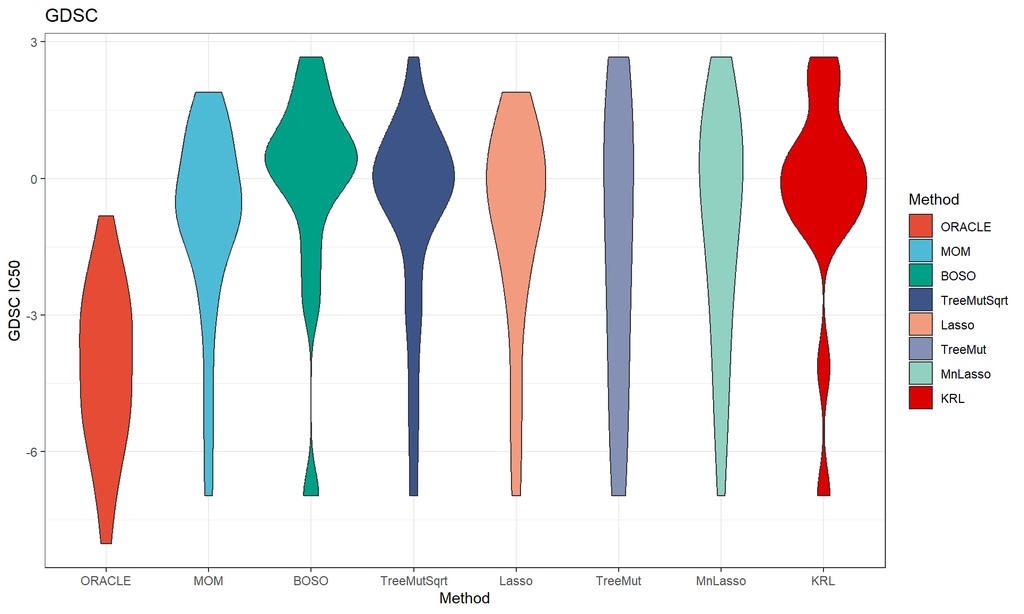

```r
Validation_plot<-data.frame(Dataset=rep("GDSC", nrow(GDSC_IC50)*8),
                                                   CellLine=rep(rownames(GDSC_IC50),8),
                                                   Method=rep(colnames(GDSC_IC50[,-1]), each=nrow(GDSC_IC50)),
                                                   IC50=unlist(GDSC_IC50[,-1]))


rownames(Validation_plot)<-1:nrow(Validation_plot)

mycomparisons<-combn(unique(Validation_plot$Method),2)
mycomparisons<-as.list(data.frame(mycomparisons))
mycomparisons<-mycomparisons[-grep("ORACLE",mycomparisons)]


Plotting<-Validation_plot[Validation_plot$Dataset=="GDSC",]


library(ggsci)

Plotting$Method<-factor(Plotting$Method, levels=c("ORACLE", "MOM", "BOSO", "TreeMutSqrt", "Lasso", "TreeMut", "MnLasso", "KRL"))

g1_gdsc<-ggplot(Plotting, aes(x=Method, y=IC50, fill=Method))+geom_violin()+
  theme_bw()+scale_fill_npg()+ylab("GDSC IC50")+ggtitle("GDSC")

g2_gdsc<-ggplot(Plotting, aes(x=Method, y=IC50, fill=Method))+geom_boxplot()+
  theme_bw()+scale_fill_npg()+ylab("GDSC IC50")+ggtitle("GDSC")

g1_gdsc
```

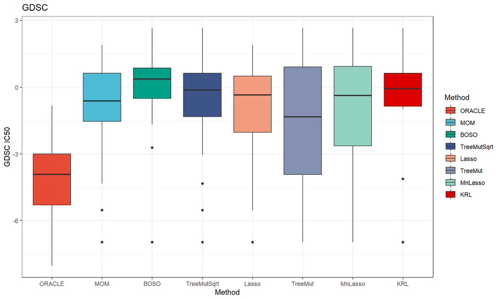

```r
g2_gdsc
```

## Intragroup Validation

We compared whether the IC50* of a drug in patients in whom it was recommended was lower than the IC50* in patients in whom it was not recommended. Using this information we compared the sensitivity to a drug for a specific group against the sensitivity to that drug for the rest of the samples by using a 2-tailed Wilcoxon test. This analysis was performed both for the BeatAML dataset (training dataset) and the GDSC AML cell lines cohort (predicted dataset).

### Obtaining MOM and KRL predicitions in all samples

```r
TratamientoMOM_All<-predictMOM_ALL(mut2)
```

```
##
##
##  Assuming Optimal BeatAML Classification
##
```

```r
identical(TratamientoMOM_All$CLs, rownames(C)) # TRUE
```

```
## [1] TRUE
```

```r
TratamientoKRL_All<- read_csv("data/output/KRL_results_all_samples_prediction.csv", show_col_types = FALSE)
TratamientoKRL_All<-TratamientoKRL_All[which(TratamientoKRL_All$Patients %in% rownames(mut2)),]
TratamientoKRL_All$DrugName[which(!(TratamientoKRL_All$DrugName %in% colnames(C)))]<-NA
```

### Intragroup Validation in BeatAML

```r
# 1. BeatAML--------------------------------------------------------------------

Validation_Beat<-data.frame(patients=rep(rownames(C),7),
                            drug=c(colnames(C)[TratamientoTreeMut_ALL],
                                   colnames(C)[TratamientoTreeMut1_All],
                                   colnames(C)[TratamientoMnLassoMut_All],
                                   colnames(C)[TratamientoLassoMut_All],
                                   colnames(C)[TratamientoBOSOMut_All],
                                   colnames(C)[TratamientoMOM_All$Treatment],
                                   TratamientoKRL_All$DrugName),
                            IC50=c(C[cbind(1:nrow(C), TratamientoTreeMut_ALL)],
                                   C[cbind(1:nrow(C), TratamientoTreeMut1_All)],
                                   C[cbind(1:nrow(C), TratamientoMnLassoMut_All)],
                                   C[cbind(1:nrow(C), TratamientoLassoMut_All)],
                                   C[cbind(1:nrow(C), TratamientoBOSOMut_All)],
                                   C[cbind(1:nrow(C), TratamientoMOM_All$Treatment)],
                                   C[cbind(TratamientoKRL_All$Patients,TratamientoKRL_All$DrugName )]),
                            Method=rep(unique(Tratamiento_plot$Method[!(Tratamiento_plot$Method=="ORACLE")]), each=nrow(C)))
```

#### MOM

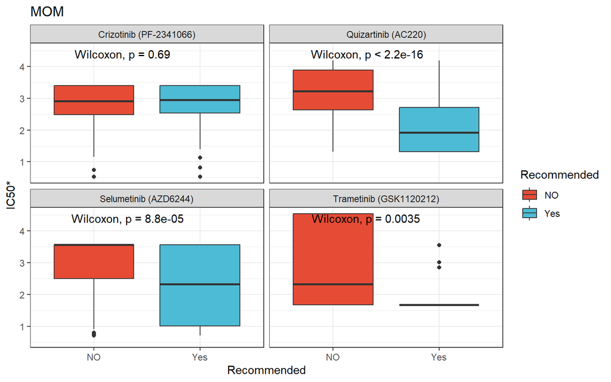

```r
Plot_aux<-Validation_Beat[Validation_Beat$Method=="MOM",]

MOM_plots<-NULL

for(j in 1:length(unique(Plot_aux$drug))){
  d<-unique(Plot_aux$drug)[j]
  ind<-Plot_aux$drug==d
  plotDrug<-data.frame(Drug=j,
                       drugname=d,
                       Patients=Plot_aux$patients,
                       IC50=NA,
                       Recommended="No")

  plotDrug$Recommended[ind]<-"Yes"
  plotDrug$IC50[ind]<-Plot_aux$IC50[ind]
  plotDrug$IC50[!ind]<-C[!ind, d]
  plotDrug$Recommended[!ind]<-"NO"

  MOM_plots<-rbind(MOM_plots,plotDrug)

}

gg1_validation_beat<-ggplot(MOM_plots, aes(x=Recommended, y=IC50, fill=Recommended))+
  geom_boxplot()+facet_wrap(~drugname)+theme_bw()+
  scale_fill_npg()+stat_compare_means(vjust = 1)+ylab("IC50*")+ggtitle("MOM")

gg1_validation_beat
```

#### TreeMut

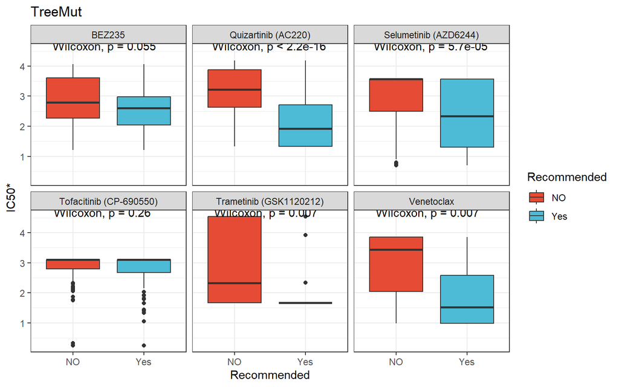

```r
#### TREE MUT

Plot_aux<-Validation_Beat[Validation_Beat$Method=="TreeMut",]

Tree_plots<-NULL

for(j in 1:length(unique(Plot_aux$drug))){
  d<-unique(Plot_aux$drug)[j]
  ind<-Plot_aux$drug==d
  plotDrug<-data.frame(Drug=j,
                       drugname=d,
                       Patients=Plot_aux$patients,
                       IC50=NA,
                       Recommended="No")

  plotDrug$Recommended[ind]<-"Yes"
  plotDrug$IC50[ind]<-Plot_aux$IC50[ind]
  plotDrug$IC50[!ind]<-C[!ind, d]
  plotDrug$Recommended[!ind]<-"NO"

  Tree_plots<-rbind(Tree_plots,plotDrug)

}

gg3_validation_beat<-ggplot(Tree_plots, aes(x=Recommended, y=IC50, fill=Recommended))+
  geom_boxplot()+facet_wrap(~drugname)+theme_bw()+scale_fill_npg()+
  stat_compare_means()+ylab("IC50*")+ggtitle("TreeMut")
gg3_validation_beat
```

#### TreeMutSqrt

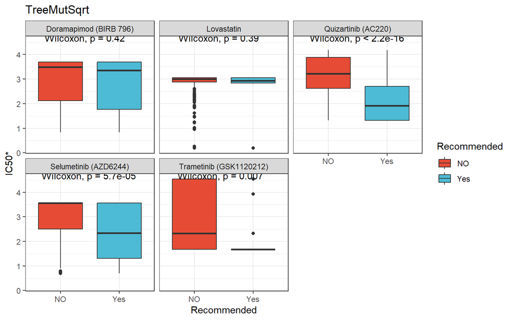

```r
### TREE MUT SQRT

Plot_aux<-Validation_Beat[Validation_Beat$Method=="TreeMutSqrt",]

TreeSQR_plots<-NULL

for(j in 1:length(unique(Plot_aux$drug))){
  d<-unique(Plot_aux$drug)[j]
  ind<-Plot_aux$drug==d
  plotDrug<-data.frame(Drug=j,
                       drugname=d,
                       Patients=Plot_aux$patients,
                       IC50=NA,
                       Recommended="No")

  plotDrug$Recommended[ind]<-"Yes"
  plotDrug$IC50[ind]<-Plot_aux$IC50[ind]
  plotDrug$IC50[!ind]<-C[!ind, d]
  plotDrug$Recommended[!ind]<-"NO"

  TreeSQR_plots<-rbind(TreeSQR_plots,plotDrug)

}

gg4_validation_beat<-ggplot(TreeSQR_plots, aes(x=Recommended, y=IC50, fill=Recommended))+
  geom_boxplot()+facet_wrap(~drugname)+theme_bw()+scale_fill_npg()+
  stat_compare_means()+ylab("IC50*")+ggtitle("TreeMutSqrt")

gg4_validation_beat
```

#### BOSO

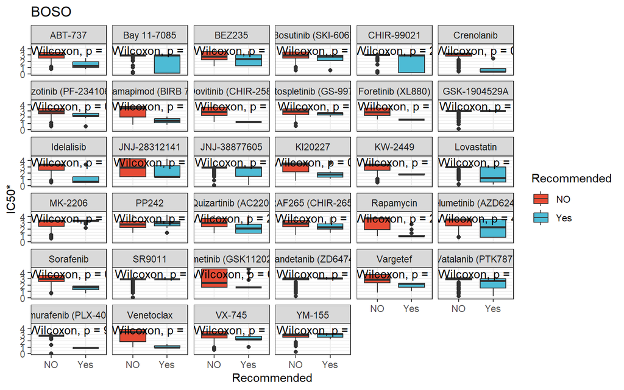

```r
### BOSO

Plot_aux<-Validation_Beat[Validation_Beat$Method=="BOSOMut",]

BOSO_plots<-NULL

for(j in 1:length(unique(Plot_aux$drug))){
  d<-unique(Plot_aux$drug)[j]
  ind<-Plot_aux$drug==d
  plotDrug<-data.frame(Drug=j,
                       drugname=d,
                       Patients=Plot_aux$patients,
                       IC50=NA,
                       Recommended="No")

  plotDrug$Recommended[ind]<-"Yes"
  plotDrug$IC50[ind]<-Plot_aux$IC50[ind]
  plotDrug$IC50[!ind]<-C[!ind, d]
  plotDrug$Recommended[!ind]<-"NO"

  BOSO_plots<-rbind(BOSO_plots,plotDrug)

}

gg2_validation_beat<-ggplot(BOSO_plots, aes(x=Recommended, y=IC50, fill=Recommended))+
  geom_boxplot()+facet_wrap(~drugname)+theme_bw()+scale_fill_npg()+
  stat_compare_means(vjust = 1)+ylab("IC50*")+ggtitle("BOSO")

gg2_validation_beat
```

#### Multinomial

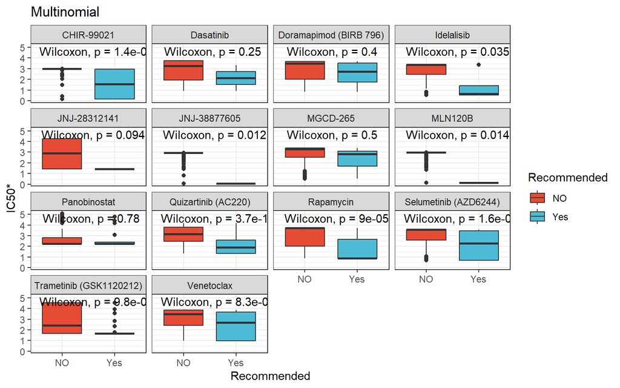

```r
#### MULTINOMIAL

Plot_aux<-Validation_Beat[Validation_Beat$Method=="Multinomial",]

MnLasso_plots<-NULL

for(j in 1:length(unique(Plot_aux$drug))){
  d<-unique(Plot_aux$drug)[j]
  ind<-Plot_aux$drug==d
  plotDrug<-data.frame(Drug=j,
                       drugname=d,
                       Patients=Plot_aux$patients,
                       IC50=NA,
                       Recommended="No")

  plotDrug$Recommended[ind]<-"Yes"
  plotDrug$IC50[ind]<-Plot_aux$IC50[ind]
  plotDrug$IC50[!ind]<-C[!ind, d]
  plotDrug$Recommended[!ind]<-"NO"

  MnLasso_plots<-rbind(MnLasso_plots,plotDrug)

}

gg5_validation_beat<-ggplot(MnLasso_plots, aes(x=Recommended, y=IC50, fill=Recommended))+
  geom_boxplot()+facet_wrap(~drugname)+theme_bw()+scale_fill_npg()+
  stat_compare_means(vjust=1)+ylab("IC50*")+ggtitle("Multinomial")
gg5_validation_beat
```

#### KRL

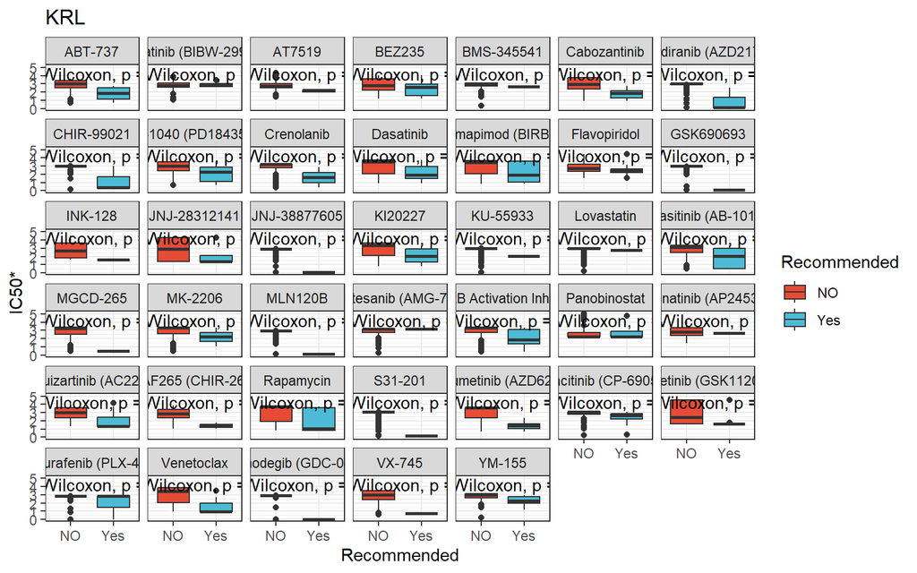

```r
#### KRL

Plot_aux<-Validation_Beat[Validation_Beat$Method=="KRL",]

KRL_plots<-NULL

for(j in 1:length(unique(Plot_aux$drug))){
  d<-unique(Plot_aux$drug)[j]
  if(is.na(d)){next}
  ind<-na.omit(Plot_aux$drug==d)
  plotDrug<-data.frame(Drug=j,
                       drugname=d,
                       Patients=Plot_aux$patients,
                       IC50=NA,
                       Recommended="No")

  plotDrug$Recommended[ind]<-"Yes"
  plotDrug$IC50[ind]<-Plot_aux$IC50[ind]
  plotDrug$IC50[!ind]<-C[!ind, d]
  plotDrug$Recommended[!ind]<-"NO"

 KRL_plots<-rbind(KRL_plots,plotDrug)

}

gg7_validation_beat<-ggplot(KRL_plots, aes(x=Recommended, y=IC50, fill=Recommended))+
  geom_boxplot()+facet_wrap(~drugname)+theme_bw()+scale_fill_npg()+
  stat_compare_means(vjust=1)+ylab("IC50*")+ggtitle("KRL")

gg7_validation_beat
```

### GDSC

```r
identical(colnames(Mutations_AML_GDSC), colnames(mut2)) #TRUE
```

```
## [1] TRUE
```

```r
Guideline_TreeMutSqrt<-predictTreeMut(treeMut1_All,C, Mutations_AML_GDSC)
Guideline_TreeMutSqrt<-colnames(C)[Guideline_TreeMutSqrt]


Guideline_BOSO<-predictBOSO(BOSOMut_All,Mutations_AML_GDSC)
Guideline_BOSO<-colnames(C)[Guideline_BOSO]

Guideline_TreeMut<-predictTreeMut(treeMut_All,C, Mutations_AML_GDSC)
Guideline_TreeMut<-colnames(C)[Guideline_TreeMut]

Guideline_Multinomial<-predictMnLasso(MnLassoMut_All, Mutations_AML_GDSC)
Guideline_Multinomial<-colnames(C)[Guideline_Multinomial]

Guideline_Lasso<-predictLasso(LassoMut_All, Mutations_AML_GDSC)
Guideline_Lasso<-colnames(C)[Guideline_Lasso]

Guideline_MOM<-predictMOM_ALL(Mutations_AML_GDSC)
```

```
##
##
##  Assuming Optimal BeatAML Classification
##
```

```r
Guideline_MOM<-colnames(C)[Guideline_MOM$Treatment]

Guideline_KRL<-read_csv("data/output/KRL_GDSC_pred.csv")
```

```r
Guideline_KRL$DrugName[which(!(Guideline_KRL$DrugName %in% colnames(C)))]<-NA
Guideline_KRL<-Guideline_KRL$DrugName

Validation_GDSC<-data.frame(patients=rep(rownames(GDSC_AML),7),
                            drug=c(Guideline_TreeMut,
                                   Guideline_TreeMutSqrt,
                                   Guideline_Multinomial,
                                   Guideline_Lasso,
                                   Guideline_BOSO,
                                   Guideline_MOM,
                                   Guideline_KRL),
                            IC50=NA,
                            Method=rep(unique(Tratamiento_plot$Method[!(Tratamiento_plot$Method=="ORACLE")]), each=nrow(GDSC_AML)))
```

#### MOM

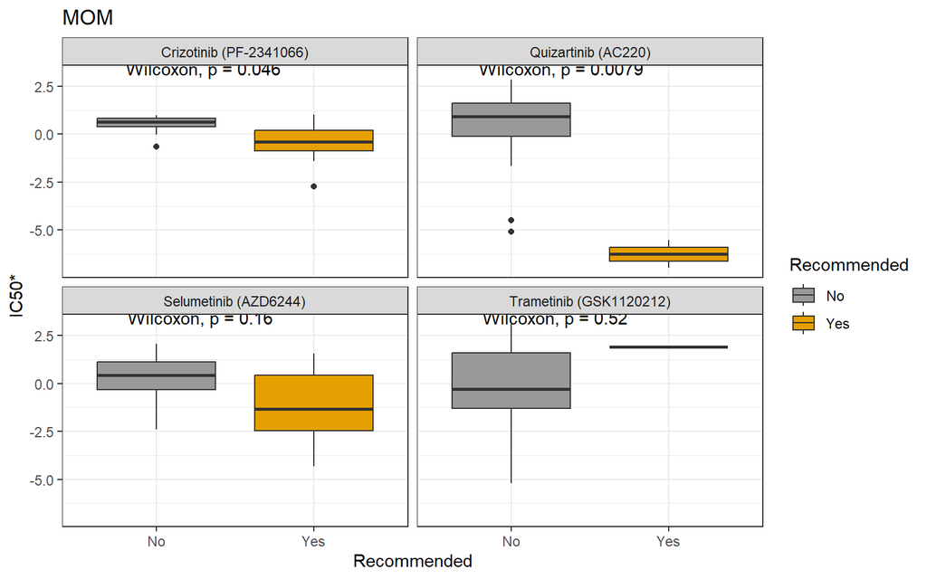

```r
### MOM

Plot_aux<-Validation_GDSC[Validation_GDSC$Method=="MOM",]

MOM_plots<-NULL

for(j in 1:length(unique(Plot_aux$drug))){
  d<-unique(Plot_aux$drug)[j]
  ind<-Plot_aux$drug==d
  plotDrug<-data.frame(Drug=j,
                       drugname=d,
                       Patients=Plot_aux$patients,
                       IC50=NA,
                       Recommended="No")

  plotDrug$Recommended[ind]<-"Yes"
  plotDrug$IC50[ind]<-GDSC_AML[ind,d]
  plotDrug$IC50[!ind]<-GDSC_AML[!ind, d]
  plotDrug$Recommended[!ind]<-"No"

  MOM_plots<-rbind(MOM_plots,plotDrug)

}

MOM_plots$Recommended<-factor(MOM_plots$Recommended, levels=c("No", "Yes"))

gg1_validation_gdsc<-ggplot(MOM_plots, aes(x=Recommended, y=IC50, fill=Recommended))+
  geom_boxplot()+facet_wrap(~drugname)+theme_bw()+scale_fill_manual(values=c("#999999", "#E69F00"))+
  stat_compare_means()+ylab("IC50*")+ggtitle("MOM")

gg1_validation_gdsc
```

#### TreeMut

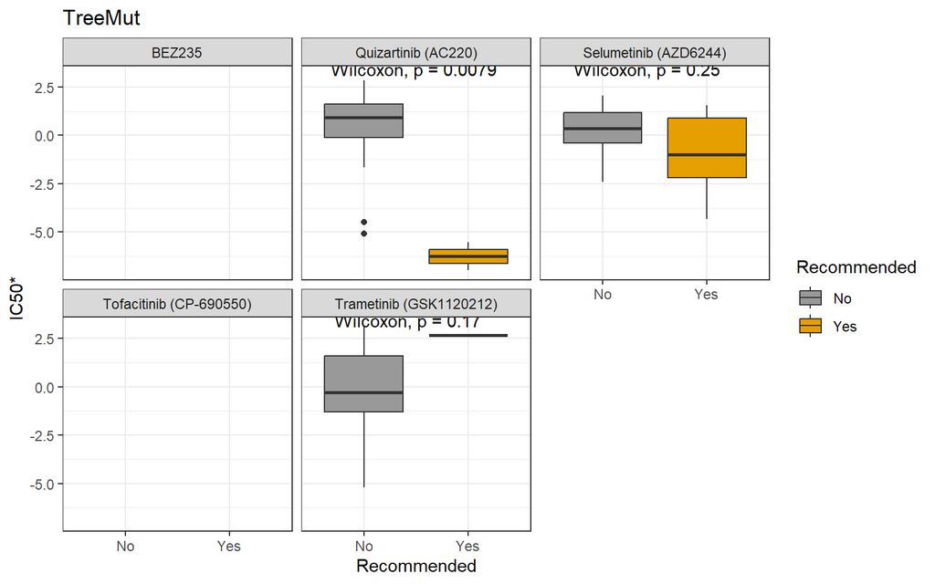

```r
#### TREE MUT

Plot_aux<-Validation_GDSC[Validation_GDSC$Method=="TreeMut",]

Tree_plots<-NULL

for(j in 1:length(unique(Plot_aux$drug))){
  d<-unique(Plot_aux$drug)[j]
  ind<-Plot_aux$drug==d
  plotDrug<-data.frame(Drug=j,
                       drugname=d,
                       Patients=Plot_aux$patients,
                       IC50=NA,
                       Recommended="No")

  plotDrug$Recommended[ind]<-"Yes"
  if(d %in% colnames(GDSC_AML)){
    plotDrug$IC50[ind]<-GDSC_AML[ind,d]
    plotDrug$IC50[!ind]<-GDSC_AML[!ind, d]
    plotDrug$Recommended[!ind]<-"No"
  }


  Tree_plots<-rbind(Tree_plots,plotDrug)

}

gg3_validation_gdsc<-ggplot(Tree_plots, aes(x=Recommended, y=IC50, fill=Recommended))+
  geom_boxplot()+facet_wrap(~drugname)+theme_bw()+scale_fill_manual(values=c("#999999", "#E69F00"))+
  stat_compare_means()+ylab("IC50*")+ggtitle("TreeMut")

gg3_validation_gdsc
```

#### TreeMutSqrt

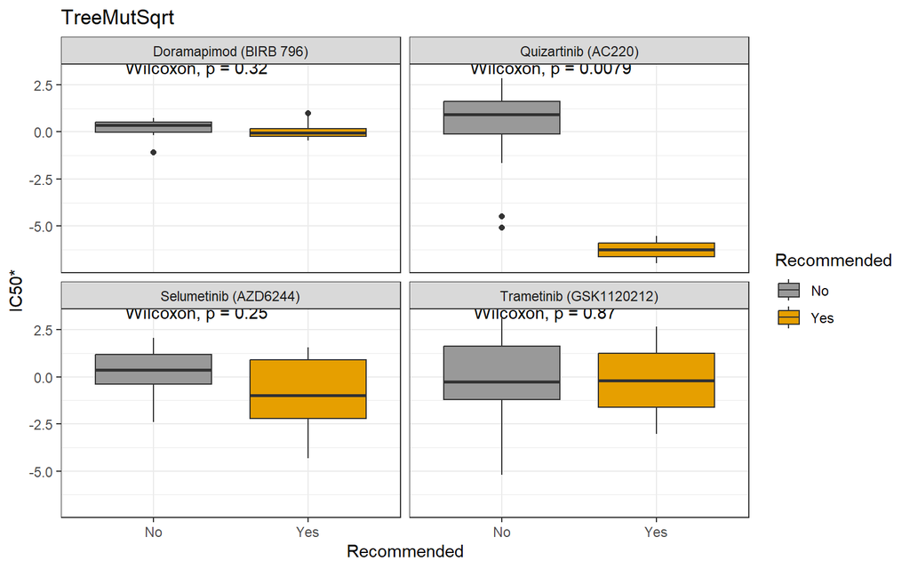

```r
### TREE MUT SQRT

Plot_aux<-Validation_GDSC[Validation_GDSC$Method=="TreeMutSqrt",]

TreeSQR_plots<-NULL

for(j in 1:length(unique(Plot_aux$drug))){
  d<-unique(Plot_aux$drug)[j]
  ind<-Plot_aux$drug==d
  plotDrug<-data.frame(Drug=j,
                       drugname=d,
                       Patients=Plot_aux$patients,
                       IC50=NA,
                       Recommended="No")
  if(d %in% colnames(GDSC_AML)){
    plotDrug$Recommended[ind]<-"Yes"
    plotDrug$IC50[ind]<-GDSC_AML[ind,d]
    plotDrug$IC50[!ind]<-GDSC_AML[!ind, d]
    plotDrug$Recommended[!ind]<-"No"
  }


  TreeSQR_plots<-rbind(TreeSQR_plots,plotDrug)

}

gg4_validation_gdsc<-ggplot(TreeSQR_plots, aes(x=Recommended, y=IC50, fill=Recommended))+
  geom_boxplot()+facet_wrap(~drugname)+theme_bw()+scale_fill_manual(values=c("#999999", "#E69F00"))+
  stat_compare_means()+ylab("IC50*")+ggtitle("TreeMutSqrt")

gg4_validation_gdsc
```

## Multiomics in BeatAML

### Load expression data

```r
# # Read expression data
Expression <- read_excel("./data/input/41586_2018_623_MOESM3_ESM.xlsx",
                         sheet = "Table S8-Gene Counts RPKM")

# Keep genes with the largest variance
ngenes <- 1000
Expression <- as.data.frame(Expression)
rownames(Expression) <- Expression[,2]
Expression <- Expression[,-c(1,2)]
OldExpression <- as.matrix(Expression)
sdevs <- rowSds(OldExpression)
# sdevs <- rowMedians(OldExpression)

Keep <- which(order(sdevs, decreasing = T) <= ngenes)
Expression <- Expression[Keep,]

commonPatients <- intersect(rownames(C), colnames(Expression))
Expression <- Expression[,commonPatients]
Expression <- t(Expression)

C <- C[commonPatients, ]
X<-mut2
X<-X[commonPatients, ]
Y <- exp(-.5*C) # Convert weights into pseudoprobabilities
Y <- Y /rowSums(Y) # Probabilities sum up one
```

### Train Models with Expression Data

```r
library(robustbase)
set.seed(2022)
Folds <- 5
Groups <- sample(1:Folds, nrow(C), replace = T)
TratamientoMnLasso <- TratamientoLasso <- TratamientoTree <- TratamientoTree1 <- rep(NA, length(Groups))
TratamientoMnLassoMut <- TratamientoLassoMut <- TratamientoTreeMut <- TratamientoTreeMut1 <- rep(NA, length(Groups))

for (group in 1:Folds) {
  cat("Fold: ", group, "\n")
  Dejar <- Groups != group
  Quitar <- !Dejar

  # Trees
  cat("Trees\n")
  tree <- trainTree(Expression[Dejar,], C[Dejar,], minbucket = 20)
  TratamientoTree[Quitar] <- predictTree(tree,C[Quitar,], Expression[Quitar,])

  # Trees sqrt
  cat("Trees sqrt\n")
  tree1 <- trainTree(Expression[Dejar,], (C[Dejar,])^.5, minbucket = 20)
  TratamientoTree1[Quitar] <- predictTree(tree1,C[Quitar,], Expression[Quitar,])

  # Using MnLasso
  cat("Multinomial Lasso\n")
  MnLasso <- trainMnLasso(Expression[Dejar,], Y[Dejar,])
  TratamientoMnLasso[Quitar] <- predictMnLasso(MnLasso,Expression[Quitar,])

  # Using Lasso
  cat("Lasso\n")
  Lasso <- trainLasso(Expression[Dejar,], C[Dejar,])
  TratamientoLasso[Quitar] <- predictMnLasso(Lasso,Expression[Quitar,])

  # TreesMut
  cat("TreesMut\n")
  treeMut <- trainTreeMut(X[Dejar,], C[Dejar,], minbucket = 20)
  TratamientoTreeMut[Quitar] <- predictTreeMut(treeMut,C[Quitar,], X[Quitar,])

  # TreesMut sqrt
  cat("TreesMut sqrt\n")
  treeMut1 <- trainTreeMut(X[Dejar,], (C[Dejar,])^.5, minbucket = 20)
  TratamientoTreeMut1[Quitar] <- predictTreeMut(treeMut1,C[Quitar,], X[Quitar,])

  # Using MnLasso
  cat("Multinomial Lasso Mut\n")
  MnLassoMut <- trainMnLasso(X[Dejar,], Y[Dejar,])
  TratamientoMnLassoMut[Quitar] <- predictMnLasso(MnLassoMut,X[Quitar,])

  # Using Lasso
  cat("Lasso Mut\n")
  LassoMut <- trainLasso(X[Dejar,], C[Dejar,])
  TratamientoLassoMut[Quitar] <- predictLasso(LassoMut,X[Quitar,])

}
```

```
## Fold:  1
## Trees
## Trees sqrt
## Multinomial Lasso
## Lasso
## TreesMut
## TreesMut sqrt
## Multinomial Lasso Mut
## Lasso Mut
## Fold:  2
## Trees
## Trees sqrt
## Multinomial Lasso
## Lasso
## TreesMut
## TreesMut sqrt
## Multinomial Lasso Mut
## Lasso Mut
## Fold:  3
## Trees
## Trees sqrt
## Multinomial Lasso
## Lasso
## TreesMut
## TreesMut sqrt
## Multinomial Lasso Mut
## Lasso Mut
## Fold:  4
## Trees
## Trees sqrt
## Multinomial Lasso
## Lasso
## TreesMut
## TreesMut sqrt
## Multinomial Lasso Mut
## Lasso Mut
## Fold:  5
## Trees
## Trees sqrt
## Multinomial Lasso
## Lasso
## TreesMut
## TreesMut sqrt
## Multinomial Lasso Mut
## Lasso Mut
```

```r
# # BOSO should be included in the loop. However, the difference between train and test is not that large.
# # Let's see how it works out of the box

#BOSO <- trainBOSO(Expression, C)
#TratamientoBOSO <- predictBOSO(BOSO, Expression)

set.seed(2021)
Folds <- 5
Groups <- sample(1:Folds, 257, replace = T)

# Use same groups as previously
TratamientoBOSO <- TratamientoBOSOMutasso <- rep(NA, length(Groups))

for (group in 1:Folds) {
  BOSO <- trainBOSO(Expression[Dejar,], C[Dejar,],maxVarsBlock = 10, standardize=F, IC = "eBIC")
  TratamientoBOSO[Quitar] <- predictBOSO(BOSO, Expression[Quitar,])
  BOSOMut <- trainBOSO(X[Dejar,], C[Dejar,],maxVarsBlock = 10, standardize=F, IC = "eBIC")
  TratamientoBOSOMut[Quitar] <- predictBOSO(BOSOMut, X[Quitar,])
}
```

```
## 17-AAG (Tanespimycin)
## Iteration 1   number of variables: 1000   block size: 10
## Iteration 2   number of variables: 90     block size: 10
## Iteration 3   number of variables: 35     block size: 10
## Iteration 4   number of variables: 19     block size: 10
## Final problem:    number of variables: 10
## Elapsed time: 1.003288 mins
## A-674563
## Iteration 1   number of variables: 1000   block size: 10
## Iteration 2   number of variables: 100    block size: 10
## Iteration 3   number of variables: 32     block size: 10
## Final problem:    number of variables: 12
## Elapsed time: 1.832964 mins
## ABT-737
## Iteration 1   number of variables: 1000   block size: 10
## Iteration 2   number of variables: 110    block size: 10
## Iteration 3   number of variables: 29     block size: 10
## Final problem:    number of variables: 12
## Elapsed time: 2.648829 mins
## AT7519
## Iteration 1   number of variables: 1000   block size: 10
## Iteration 2   number of variables: 107    block size: 10
## Iteration 3   number of variables: 28     block size: 10
## Final problem:    number of variables: 8
## Elapsed time: 3.437079 mins
## AZD1480
## Iteration 1   number of variables: 1000   block size: 10
## Iteration 2   number of variables: 48     block size: 10
## Final problem:    number of variables: 11
## Elapsed time: 4.075745 mins
## Afatinib (BIBW-2992)
## Iteration 1   number of variables: 1000   block size: 10
## Iteration 2   number of variables: 61     block size: 10
## Iteration 3   number of variables: 16     block size: 10
## Final problem:    number of variables: 7
## Elapsed time: 4.686606 mins
## Alisertib (MLN8237)
## Iteration 1   number of variables: 1000   block size: 10
## Iteration 2   number of variables: 42     block size: 10
## Final problem:    number of variables: 12
```

[output cut: 5260 more lines]

```
## Vismodegib (GDC-0449)
## Iteration 1   number of variables: 69     block size: 10
## Final problem:    number of variables: 5
## Elapsed time: 3.906324 mins
## Volasertib (BI-6727)
## Iteration 1   number of variables: 69     block size: 10
## Final problem:    number of variables: 1
## Elapsed time: 3.930493 mins
## XAV-939
## Iteration 1   number of variables: 69     block size: 10
## Final problem:    number of variables: 1
## Elapsed time: 3.958783 mins
## YM-155
## Iteration 1   number of variables: 69     block size: 10
## Elapsed time: 3.981222 mins
```

```r
TratamientoOracle <- apply(C, 1, which.min)

Tratamientos <- cbind(C[cbind(1:nrow(C), TratamientoOracle)],
                      C[cbind(1:nrow(C), TratamientoTree)],
                      C[cbind(1:nrow(C), TratamientoTree1)],
                      C[cbind(1:nrow(C), TratamientoMnLasso)],
                      C[cbind(1:nrow(C), TratamientoLasso)],
                      C[cbind(1:nrow(C), TratamientoBOSO)],
                      C[cbind(1:nrow(C), TratamientoTreeMut)],
                      C[cbind(1:nrow(C), TratamientoTreeMut1)],
                      C[cbind(1:nrow(C), TratamientoMnLassoMut)],
                      C[cbind(1:nrow(C), TratamientoLassoMut)],
                      C[cbind(1:nrow(C), TratamientoBOSOMut)]
)
#
colnames(Tratamientos) <- c("Oracle","Tree","TreeSqrt","MnLasso","Lasso","BOSO",
                            "TreeMut","TreeSrqtMut","MnLassoMut","LassoMut","BOSOMut")
```

### Plotting Results

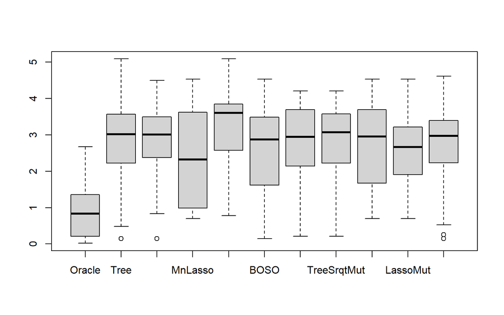

```r
boxplot(Tratamientos)
```

```r
plot_Ex_Mut<-data.frame(Method=rep(colnames(Tratamientos), each=nrow(Tratamientos)))
plot_Ex_Mut$IC50<-unlist(as.data.frame(Tratamientos))
plot_Ex_Mut$Type<-"GE"
plot_Ex_Mut$Type[grep("Mut", plot_Ex_Mut$Method)]<-"Mut"


plot_Ex_Mut<-plot_Ex_Mut[order(plot_Ex_Mut$Method),]
plot_Ex_Mut$General_Method<-"unknown"
plot_Ex_Mut$General_Method[grep("Oracle", plot_Ex_Mut$Method)]<-"Oracle"
plot_Ex_Mut$General_Method[grep("BOSO", plot_Ex_Mut$Method)]<-"BOSO"
plot_Ex_Mut$General_Method[grep("Tree", plot_Ex_Mut$Method)]<-"Tree"
plot_Ex_Mut$General_Method[grep("TreeSqrt", plot_Ex_Mut$Method)]<-"TreeSqrt"
plot_Ex_Mut$General_Method[grep("TreeSrqtMut", plot_Ex_Mut$Method)]<-"TreeSqrt"
plot_Ex_Mut$General_Method[grep("Lasso", plot_Ex_Mut$Method)]<-"Lasso"
plot_Ex_Mut$General_Method[grep("MnLasso", plot_Ex_Mut$Method)]<-"MnLasso"

# plot_Ex_Mut<-rbind(plot_Ex_Mut, data.frame(Method=NA, IC50=5, Type="Mut", General_Method="MOM"))

plot_Ex_Mut$Method<-factor(plot_Ex_Mut$Method, levels=c("Oracle","BOSO","BOSOMut","TreeSqrt","TreeSrqtMut","Lasso","LassoMut",
                                                        "Tree","TreeMut",
                                                        "MnLasso","MnLassoMut"))
plot_Ex_Mut$General_Method<-factor(plot_Ex_Mut$General_Method, levels=c("Oracle", "BOSO", "TreeSqrt", "Lasso",
                                                                        "Tree","MnLasso"))


mycomparisons<-list(c("Tree", "TreeMut"), c("TreeSqrt", "TreeSrqtMut"), c("Lasso", "LassoMut"), c("BOSO", "BOSOMut"),
                    c("MnLasso", "MnLassoMut"))
mypal = pal_npg("nrc")(9)
mypal<-mypal[c(1,3:7)]
gg_ex_mut<-ggplot(plot_Ex_Mut, aes(x=Method, y=IC50, fill=General_Method, alpha=Type))+geom_boxplot()+
  scale_fill_manual(values=mypal)+theme_bw()+ggtitle("5-fold CV in BeatAML")+ylab("IC50*")+labs(fill="General Method")+
  stat_compare_means(aes(Method),vjust=0, hjust=-1, comparisons=mycomparisons,label.y = 5)+scale_alpha_manual(values=c( 0.5, 1))
```

[output not shown]

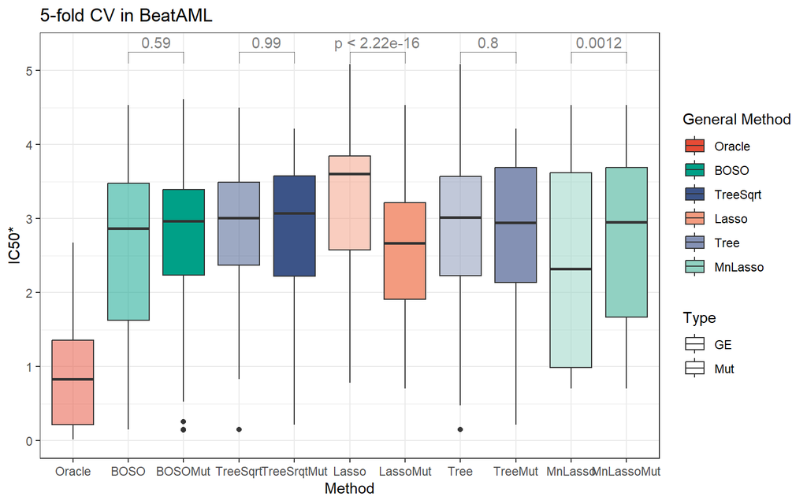

```r
gg_ex_mut
```